# Frequentist Logistic Regression

```r
library(dplyr)
library(tidyverse)
library(ggplot2)
library(loo)
library(jtools)
library(countrycode)
library(rstanarm)
library(bayesplot)
library(pROC)
```

```r
loans <- read.csv("data/loans.csv")
```

```r
loan <- loans %>%
  mutate(paid_amount = if_else(is.na(paid_amount), 0, paid_amount),
         continent = countrycode(sourcevar = location.country,
                            origin = "country.name",
                            destination = "continent"))
```

# Logistic Regression

The response variable that we would like to look at is the loan status. As shown in the EDA section, it has 8 levels. Intuitively an appropriate model for such a response variable with be a multinomial logistic regression, but that would be hard to interpret. Thus, we are only looking at the completed loans, which are either repaid or not repaid. We filtered the data set for observations whose status is “paid” or “defaulted”. With a binary response variable, we could then fit a logistic regression on the data. To start with, we mutated the `status` variable to be 1 if it was “paid” and 0 if it was “defaulted”, such that the baseline level would be “defaulted”.

```r
d <- loan %>%
  filter(status == "paid"|status == "defaulted")
d <- d %>%
  mutate(status = if_else(status == "paid", 1, 0))
```

The logistic regression model is an example of a broad class of models known as generalized linear models (GLM), in which a linear relationship between the response and predictors is built even though their underlying relationship is not linear. Since we have a single-observation binary response variable, we are using a Bernoulli GLM. A Bernoulli distributions the discrete probability distribution of a random variable which takes the value 1 with probability $p$ and the value 0 with probability $q=1-p$.The likelihood for one observation $y$ can be written as a Bernoulli PMF over possible outcomes $k$:
$$\begin{equation}
f(k;p) =
\left\{
\begin{array}{cc}
p & \mathrm{if\ } k=1 \\
1-p & \mathrm{if\ } k=0 \\
\end{array}
\right.
\end{equation},$$

The two most common link functions used for binomial GLMs are the logit and probit functions, but for binary outcomes a common choice is the *logit link.* The logit link convert probabilities to log odds, and therefore the model coefficients can be easily interpreted in terms of odds ratios. When the logit link function is used the model is often referred to as a logistic regression model (the inverse logit function is the CDF of the standard logistic distribution).

## Frequentist Approach

First, we fitted a general logistic regression model with frequentist approach. Basically, frequentist probability or frequentism is an interpretation of probability; it defines an event’s probability as the limit of its relative frequency in many trials (the long-run probability). Probabilities can be found (in principle) by a repeatable objective process (and are thus ideally devoid of opinion). The response variable we were using is `status,` since we wanted to explore which factors are affecting the loan repayment. For the predictors, we are interested in the following variables:

```r
d <- d %>%
  select(loan_id, loan_amount, status, funded_amount, posted_yr, posted_mo, posted_day, funded_yr, funded_mo, funded_day, sector, continent, borrower_m_count, borrower_f_count) %>%
  mutate(dif = loan_amount-funded_amount,
         time = (funded_yr - posted_yr)*365+(funded_mo - posted_mo)*30 + (funded_day - posted_day),
         sex = case_when(borrower_m_count == 0 ~ "female",
                         borrower_f_count == 0 ~ "male",
                         TRUE ~ "mixed"))
```

```r
unique(d$dif)
```

```
## [1] 0
```

However, a closer look at the variable `dif` showed that after we filtered the original data set to contain only completed loans, all the observations has funded amount equal to the loan amount. Thus, the variable `dif` would not make any difference on the response variable, so we were excluding it from our model.

Next, we split our data into training set and test set and fitted a frequentist logistic model on the training set:

```r
seed <- 2
train1 <- sample(d$loan_id, 30000)
training <- d %>%
  filter(loan_id %in% train1)
testing <-d %>%
  filter(!loan_id %in% train1)
model <- glm(status ~ loan_amount + sector + posted_yr + continent + time + sex, data = training, family = "binomial"(link = "logit"))
```

To identify variables that are important in explaining variation in the response, we did model selection using the `step()` function. Specifying “direction=”both”” tells R to perform both forward and backward selections. The default selection criterion is $\mathrm{AIC}$: from the current model, it drops or adds the one variable that leads to the best $\mathrm{AIC}$ improvement (smallest $\mathrm{AIC}$).

```r
step(model, direction="both",trace=FALSE)
```

```
##
## Call:  glm(formula = status ~ loan_amount + sector + posted_yr + continent +
##     time + sex, family = binomial(link = "logit"), data = training)
##
## Coefficients:
##          (Intercept)           loan_amount            sectorArts
##            -8.39e+02              1.74e-04              3.09e-01
##       sectorClothing    sectorConstruction       sectorEducation
##             5.32e-01              1.03e+00              1.41e+01
##  sectorEntertainment            sectorFood          sectorHealth
##             2.77e-01              5.31e-01              1.67e+00
##        sectorHousing   sectorManufacturing    sectorPersonal Use
##             6.72e-01              1.30e+00             -3.07e-01
##         sectorRetail        sectorServices  sectorTransportation
##             5.75e-01              2.97e-01              6.71e-01
##      sectorWholesale             posted_yr     continentAmericas
##             1.68e+00              4.19e-01              7.84e-01
##        continentAsia       continentEurope      continentOceania
##             1.55e+00              2.78e+00              1.51e+01
##                 time               sexmale              sexmixed
##             6.85e-03             -2.22e-01             -9.83e-02
##
## Degrees of Freedom: 29999 Total (i.e. Null);  29976 Residual
## Null Deviance:       6550
## Residual Deviance: 6010  AIC: 6060
```

```r
final <- glm(status ~ loan_amount + sector + posted_yr + continent + sex, data = training, family = "binomial"(link = "logit"))
```

We can see a formatted model output using the `summ()` function:

```r
summ(final)
```

| Observations | 30000 |
| --- | --- |
| Dependent variable | status |
| Type | Generalized linear model |
| Family | binomial |
| Link | logit |

| 𝛘²(22) | 530.34 |
| --- | --- |
| Pseudo-R² (Cragg-Uhler) | 0.09 |
| Pseudo-R² (McFadden) | 0.08 |
| AIC | 6062.88 |
| BIC | 6253.99 |

|  | Est. | S.E. | z val. | p |
| --- | --- | --- | --- | --- |
| (Intercept) | -854.12 | 63.28 | -13.50 | 0.00 |
| loan_amount | 0.00 | 0.00 | 3.16 | 0.00 |
| sectorArts | 0.30 | 0.26 | 1.15 | 0.25 |
| sectorClothing | 0.54 | 0.17 | 3.23 | 0.00 |
| sectorConstruction | 1.04 | 0.32 | 3.25 | 0.00 |
| sectorEducation | 14.12 | 327.24 | 0.04 | 0.97 |
| sectorEntertainment | 0.27 | 1.03 | 0.27 | 0.79 |
| sectorFood | 0.54 | 0.12 | 4.58 | 0.00 |
| sectorHealth | 1.60 | 0.59 | 2.71 | 0.01 |
| sectorHousing | 0.70 | 0.35 | 2.00 | 0.05 |
| sectorManufacturing | 1.21 | 0.42 | 2.85 | 0.00 |
| sectorPersonal Use | -0.29 | 0.47 | -0.63 | 0.53 |
| sectorRetail | 0.59 | 0.12 | 4.84 | 0.00 |
| sectorServices | 0.31 | 0.15 | 2.06 | 0.04 |
| sectorTransportation | 0.69 | 0.28 | 2.48 | 0.01 |
| sectorWholesale | 1.69 | 1.01 | 1.67 | 0.10 |
| posted_yr | 0.43 | 0.03 | 13.53 | 0.00 |
| continentAmericas | 0.79 | 0.09 | 8.70 | 0.00 |
| continentAsia | 1.56 | 0.11 | 13.84 | 0.00 |
| continentEurope | 2.79 | 0.71 | 3.91 | 0.00 |
| continentOceania | 15.16 | 201.86 | 0.08 | 0.94 |
| sexmale | -0.21 | 0.10 | -2.18 | 0.03 |
| sexmixed | -0.09 | 0.18 | -0.54 | 0.59 |

Standard errors: MLE

An example of interpretation of the coefficients is: “0.42” for `posted_yr` means that for a given year when the loan is posted, the expected odds of the loan getting repaid is $e^{0.42}\approx1.52$ times the odds of the loan getting repaid if the loan is posted the previous year.

To evaluate our model, we’re using the ROC (*Receiver Operating Characteristic*) curves to evaluate different thresholds for a classification problem. In a nutshell, ROC curve visualizes a confusion matrix for every threshold. ROC curve shows a *False positive rate* on the X-axis. This metric informs us about the proportion of negative class classified as positive. We used `ggroc()` from the `PROC` package to plot the ROC curve.

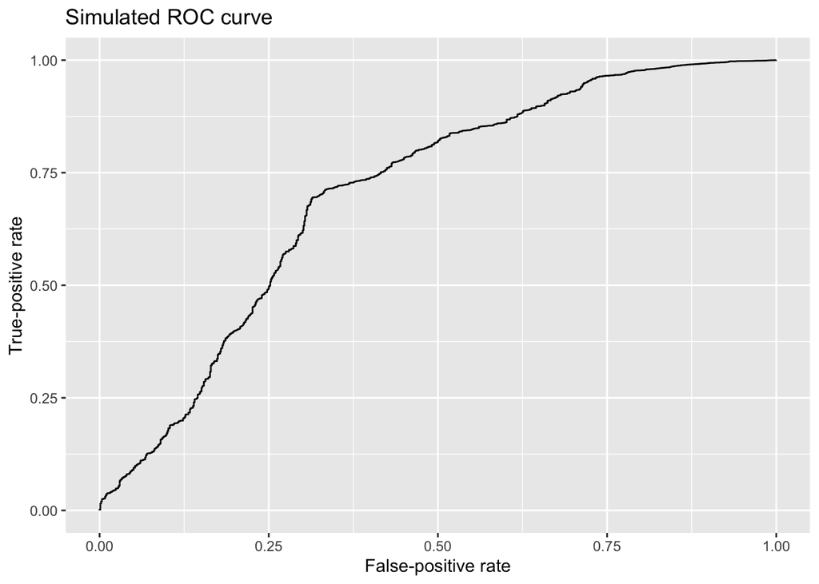

```r
predicted1 <- predict(final, newdata = testing)
roc1 = roc(response = testing$status, predictor = predicted1)
ggroc(roc1, legacy.axes = TRUE) +
  labs(x = 'False-positive rate', y = 'True-positive rate', title = 'Simulated ROC curve')
```

On the Y-axis, it shows a *True positive rate.* This metric is sometimes called *Recall* or *Sensitivity*. It shows the positive class proportion that was correctly classified.

AUC represents the area under the ROC curve. AUC ranges in value from 0 to 1. A model whose predictions are 100% wrong has an AUC of 0; one whose predictions are 100% correct has an AUC of 1. Ideally, the ROC curve should extend to the top left corner. The AUC score would be 1 in that scenario. We used the `auc()` function from the `pROC` package to calculate the AUC of the model.

```r
auc(testing$status,predicted1)
```

```
## Area under the curve: 0.705
```